# Real Estate Data Analysis

There are data set of historical prices of nearby properties. We are going to analyze this dataset and then build predictive model to estimate the selling price of the houses using the characteristics of properties.

```r
library(FNN)
library(dplyr)
import.csv <- function(filename) {
    return(read.csv(filename, sep = ",", header = TRUE))
}
# utility function for export to csv file
write.csv <- function(ob, filename) {
    write.table(ob, filename, quote = FALSE, sep = ",", row.names = FALSE)
}
# Utility function to find the number of missing values in a column
count.na <- function(v){
  return (sum(is.na(v)))
}
# Utility function to find the most common value in the column
find_MCV <- function(v){
  df.freq <- as.data.frame(sort(table(v), TRUE))
  df.freq
  mcv.vector = ""
  for(i in 1:nrow(df.freq)){
    mcv.vector <- paste(mcv.vector,as.character(df.freq[i,1]),"(",as.character(df.freq[i,2]),") ",sep = "")
    if (i == 3) break
  }
  return (mcv.vector)
}
```

```r
brief <- function(df){
  print(paste("This dataset has ", nrow(df), " rows and ", ncol(df), " columns."))
  cat("\n")

  numeric <- sapply(df,is.numeric)
  df.realValue <- df[,numeric]
  df.symbolic <- df[!numeric]
  df <- NULL

  cat("Real valued attributes","\n")
  Attribute_Id <- seq.default(ncol(df.realValue))
  Attribute_Name <- colnames(df.realValue)
  Mean <- as.vector(round(apply(df.realValue,2, mean, na.rm=T),2))
  Median <- as.vector(round(apply(df.realValue,2,median, na.rm=T),2))
  Sdev <- as.vector((round(apply(df.realValue,2, sd, na.rm=T),2)))
  Min <- as.vector(round(apply(df.realValue,2, min, na.rm=T),2))
  Max <- as.vector(round(apply(df.realValue,2, max, na.rm=T),2))
  Missing <- as.vector(round(apply(df.realValue,2, function(x) count.na(x)),2))
  output.realValue <- data.frame(Attribute_Id, Attribute_Name, Mean, Median, Sdev, Min, Max, Missing)
  print(output.realValue)

  Attribute_Id <- NULL
  Attribute_Name <- NULL
  Missing <- NULL
  cat("Symboic attributes","\n")
  Attribute_Id <- seq.default(ncol(df.symbolic))
  Attribute_Name <- colnames(df.symbolic)
  Missing <- apply(df.symbolic, 2, function(x) count.na(x))
  Arity <- as.vector(round(apply(df.symbolic, 2, function(x) length(unique(x))),2))
  MCVS_Count <- as.character((apply(df.symbolic, 2, function(x) find_MCV(x))))
  output.symbolic <- data.frame(Attribute_Id, Attribute_Name, Missing, Arity, MCVS_Count)
  rownames(output.symbolic) <- NULL
  print(output.symbolic)
}
```

High level descriptive analysis of the data

```r
df.house.data.no.missing <- import.csv("/Users/karansharma/Google Drive/DataScienceProjects/RealEstateDataAnalysis/house_no_missing.csv")
brief(df.house.data.no.missing)
```

```
[1] "This dataset has  506  rows and  9  columns."

Real valued attributes
```

| Attribute_Id | Attribute_Name | Mean | Median | Sdev | Min | Max | Missing |
| --- | --- | --- | --- | --- | --- | --- | --- |
| 1 | house_value | 225328.06 | 212000.00 | 91971.04 | 50000.00 | 500000.00 | 0 |
| 2 | Crime_Rate | 3.61 | 0.26 | 8.60 | 0.01 | 88.98 | 0 |
| 3 | num_of_rooms | 6.27 | 6.00 | 0.73 | 4.00 | 9.00 | 0 |
| 4 | dist_to_employment_center | 3.80 | 3.21 | 2.11 | 1.13 | 12.13 | 0 |
| 5 | property_tax_rate | 408.24 | 330.00 | 168.54 | 187.00 | 711.00 | 0 |
| 6 | student_teacher_ratio | 18.46 | 19.05 | 2.16 | 12.60 | 22.00 | 0 |
| 7 | Nitric_Oxides | 0.55 | 0.54 | 0.12 | 0.38 | 0.87 | 0 |
| 8 | accessiblity_to_highway | 9.55 | 5.00 | 8.71 | 1.00 | 24.00 | 0 |

```
Symboic attributes
```

| Attribute_Id | Attribute_Name | Missing | Arity | MCVS_Count |
| --- | --- | --- | --- | --- |
| 1 | Charles_river_bound | 0 | 2 | No(471) Yes(35) |

Note:

- Arity: The number of unique values for a symbolic attribute
- MCVs_counts: Most common values for an attribute and the number of records in which they appear.
- Missing: The number of missing entries for the attribute; missing values are indicated by blanks in data.

Let’s try to understand the dataset through visualization

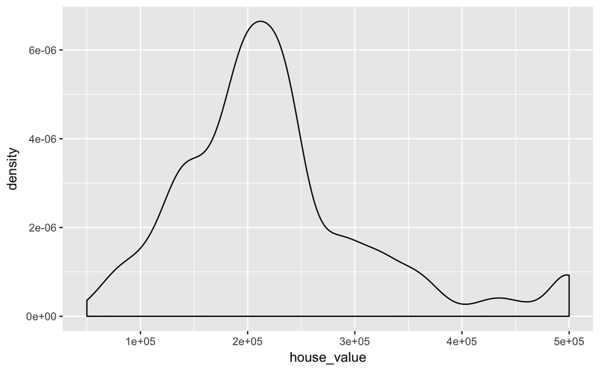

```r
p = ggplot(data = df.house.data.no.missing, aes(x=house_value))
p + geom_density(alpha = 0.1, )
```

Our target variable, house value is normally distributed with litle bit skewed to the right.

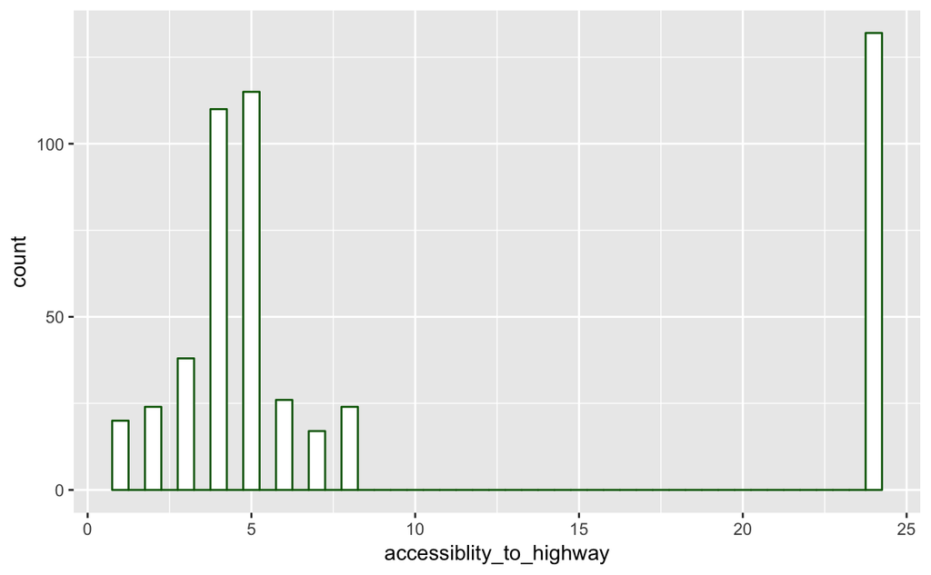

```r
library(ggplot2)
p = ggplot(data = df.house.data.no.missing, aes(x=accessiblity_to_highway))
p + geom_histogram(colour = "darkgreen", fill = "white", binwidth = 0.5)
```

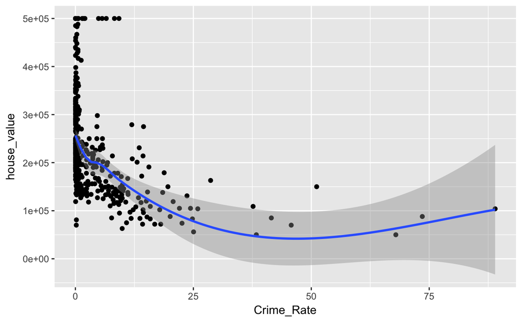

```r
p = ggplot(data = df.house.data.no.missing, aes(x=Crime_Rate, y=house_value))
p + geom_point() + geom_smooth()
```

Overall trend says that the house value is decreasing with the increasing crime rate. The outliers in the end pulling the trend upward.

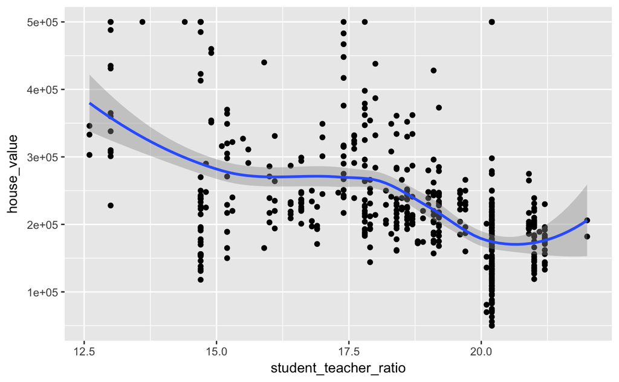

```r
p = ggplot(data = df.house.data.no.missing, aes(x=student_teacher_ratio, y=house_value))
p + geom_point() + geom_smooth()
```

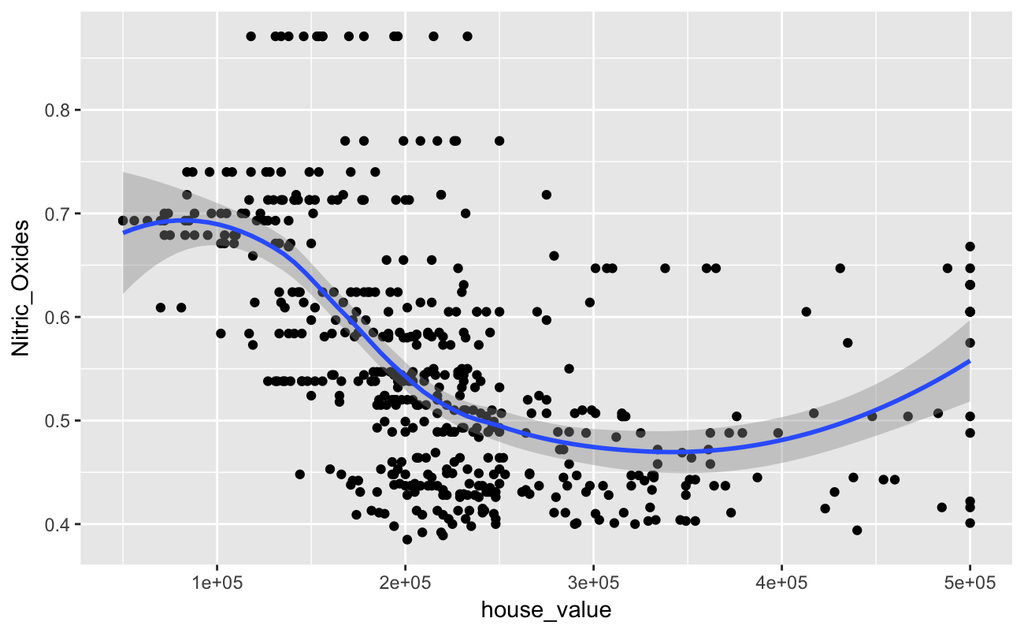

```r
p = ggplot(data = df.house.data.no.missing, aes(x=house_value, y=Nitric_Oxides))
p + geom_point() + geom_smooth()
```

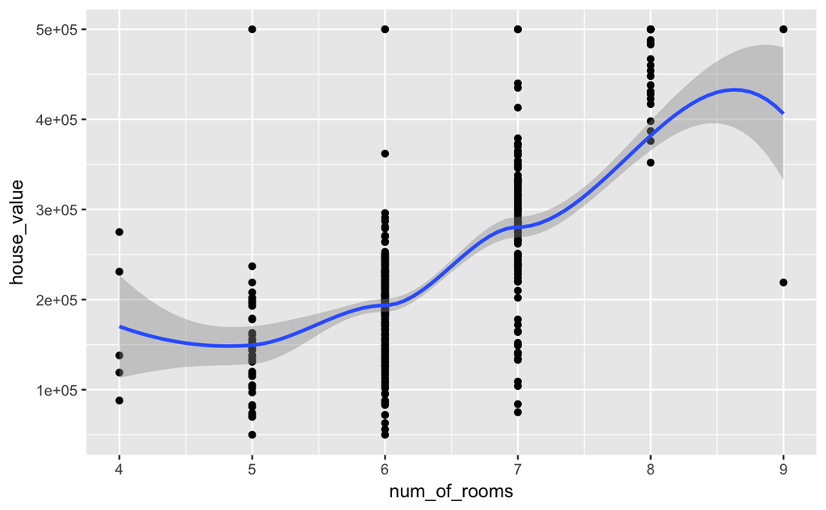

```r
p = ggplot(data = df.house.data.no.missing, aes(y=house_value, x=num_of_rooms))
p + geom_point() + geom_smooth()
```

High number of rooms increaing the house value, as expected.

We are going to try out predictive models:

1. Default Model
2. Linear Model
3. Nearest Neighbor

Each function trains the model using K fold cross validations and returns a vector of root mean sq error for each fold

```r
# Assumes the last column of data is the output dimension lets build some models
# Connect-the-dots model that learns from train set and is being tested using test
get_pred_dots <- function(train,test){
  nf <- ncol(train)
  input <- data.matrix(train[,-nf])
  query <- data.matrix(test[,-nf])
  my.knn <- get.knnx(input,query,k=2) # Get two nearest neighbors
  nn.index <- my.knn$nn.index
  pred <- rep(NA,nrow(test))
  for (ii in 1:nrow(test)){
    y1 <- train[nn.index[ii,1],nf]
    y2 <- train[nn.index[ii,2],nf]
    pred[ii] = (y1+y2)/2
  }
  return(pred)
}
#linear model
get_pred_lr <- function(train,test){
  nf = ncol(train)
  my.regression <- lm(house_value~., data = train)
  output <- predict(my.regression,test)
  return(output)
}
# Default predictor model
get_pred_default <- function(train,test){
  nf <- ncol(test)
  output <- mean(train[,nf], na.rm = TRUE)
  output <- rep(output, each = nrow(test))
  return (output)
}
# Function that returns Root Mean Squared Error
rmse <- function(error){
  sqrt(mean(error^2))
}
# Function will do K time cross validation and return a vector of length k of root mean sqr error obtained for model with output target variable
do_cv<- function(df, output, k, model ){

  #moving the output to the last using pipe operator in the dplyr
  df <- df %>% select(-starts_with(output),everything())

  #cutting the dataframe into k pieces
  folds <- cut(seq(1,nrow(df)), breaks = k, labels=FALSE)

  output<-vector()
  predValue<-vector()

  for(i in 1:k){

    t <- which(folds==i,arr.ind=TRUE)
    test <- df[t, ]
    train <- df[-t, ]

    if(model=='get_pred_default'){
      predValue <- c(get_pred_default(train,test))
    }

    if(model=='get_pred_lr'){
      predValue <- c(get_pred_lr(train,test))
    }

    if(model=='get_pred_dots'){
      predValue <- c(get_pred_dots(train,test))
    }

    error <- c(test[,ncol(test)]) - predValue

    output <- c(output,rmse(error))
  }
  output
}
```

Now, we are going to call each model and get the mean value of RMSE for each model

```r
df.house.data.no.missing <-  import.csv("/Users/karansharma/Google Drive/DataScienceProjects/RealEstateDataAnalysis/house_no_missing.csv")
rmse.defualt.model <- do_cv(df.house.data.no.missing, 'house_value', 10, 'get_pred_default')
t.test.default <- t.test(rmse.defualt.model)
conf.int.default.model <- t.test.default$conf.int[1:2]
mean_default_model <- t.test.default$estimate
rmse.lr.model <- do_cv(df.house.data.no.missing, 'house_value', 10, 'get_pred_lr')
t.test.lr <- t.test(rmse.lr.model)
conf.int.lr <- t.test.lr$conf.int[1:2]
mean_lr_model <- t.test.lr$estimate
rmse.kmm.model <- do_cv(df.house.data.no.missing, 'house_value', 10, 'get_pred_dots')
t.test.kmm <- t.test(rmse.kmm.model)
conf.int.kmm <- t.test.kmm$conf.int[1:2]
mean_Knn_model <- t.test.kmm$estimate
```

Let’s compare the models:

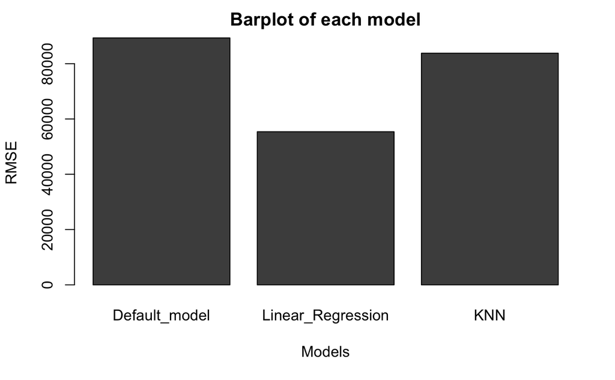

```r
barplot(cbind(Default_model = mean_default_model,
          Linear_Regression = mean_lr_model,
          KNN = mean_Knn_model), xlab = 'Models', ylab = 'RMSE',
           main = "Barplot of each model")
```

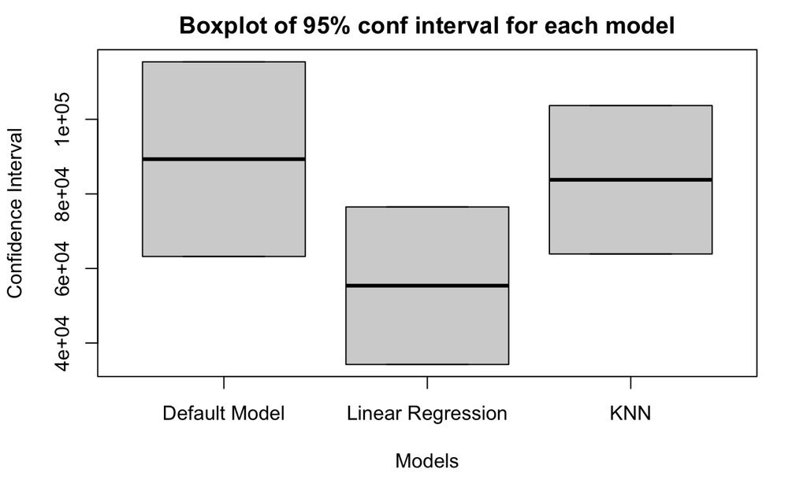

```r
boxplot(x = conf.int.default.model,conf.int.lr,conf.int.kmm,
        names = c('Default Model', 'Linear Regression', 'KNN'),
        col = "lightgray",
        xlab = "Models",
        ylab = "Confidence Interval",
        main = "Boxplot of 95% conf interval for each model"
        )
```

Boxplot and Barplot suggest that linear regression has the least RMSE. Second is the nearest neighbour and last is the default model.